# Donald Trump May Win His Re-election Campaign?

Prediction on 2020 US Presidential Election

Yijie Zhao, Yifan Xu, Yuyan Xu & Yuze Kang

1 November 2020

# Introduction

The presidential election campaign is held every four years. Before the official campaign day, American political analysts and scholars typically spent hours dedicating in forecasting the winner of election. This is a national matter such that every U.S. citizen deeply cares about. The last election in 2016, Donald Trump lost the popular vote against Hillary Clinton but still won the election and became the new U.S. president. His vote share was mostly located in the rural and suburban areas, where he won 70% of the popular vote; Clinton on the other hand, had a vote share located in densely populated areas (Hennig, 2017). Although Clinton won the popular vote, the winning majority in the Electoral College leaned towards the republican candidate, as a result, Trump won by securing the votes in some of the important swing states (Hennig, 2017). This year, the U.S. election seems more intriguing and uncertain under the shadows of COVID-19. The two candidates that have dominant polling are Donald Trump and the Democratic presidential nominee Joe Biden. Polling research have observed that the American voters changed their concerns and behaviour due to the effects of COVID-19, their major concern were the economy (Zhang & Fedor, 2020). The October polling showed that about 53 percent of Democrats believed they were worse off financially since Trump became president and 9 percent of Republicans do (Zhang & Fedor, 2020). This shows that voters are starting to reconsider their choices of candidate because the pandemic has brought doubts and criticisms on Trump’s policy on dealing with the spreading of the disease. However, the lap in national polls does not mean that Trump will lose the election on November 3. This report is in an effort to predict the outcome of election by constructing statistical models to analyze the current voting trend. We eliminated the other candidates and only consider the two candidates with dominant polling, Donald Trump and Joe Biden. Our objective is to discover the voter’s behaviour and how they think of Donald Trump, and then predict the chance of Donald Trump win the 2020 election by using these analytic findings.

In this report, we used the first release of the Phase 2 data in August 2020 from UCLA Nationalscape as our survey data. The dataset we chose was the wave 50 of the Nationalscape data (20200625). In addition to this, we also used the 2018 census data from American Community Surveys (ACS) as our post-stratification data. Post-stratification is an statistical method that allows adjusting the samples in order to match the general population. When conducting the survey, pollsters often need to deal with nonresponse from the potential respondents. These nonresponses could contribute to a bias on the research findings such that they cannot reflect on the real large population. Post-stratification is a way to deal with the nonresponse situation. In this survey, we first cleaned the data by identifying any errors in the data and removed them. In the data section, we used bar plots and histograms to analyze the demographic information about the voters who voted Donald Trump in each dataset.

# Data

In this report, we used the first release of the Phase 2 data in August 2020 from UCLA Nationalscape. The dataset we chose was the wave 50 of the Nationalscape data (20200625) (Tausanovitch and Vavreck (2020)), which treated as an individual level survey data to predict the outcome of the election on 2020. Meanwhile, we used the data set of American Community Surveys (ACS) in 2018 as the post-stratification data, aiming at making the best estimate of the election result. (Steven Ruggles and Sobek (n.d.)) We also used Larmarange (2020) and Wickham and Miller (2020) in data cleaning.

## Survey data

The survey data was released by Nationscape. The Democracy Fund + UCLA Nationscape is one of the largest public opinion survey projects. It interviewed people in almost every county, congressional district, and mid-sized American cities in the lead up to the upcoming election.

The Nationscape’s survey on the 2020 US election intends to interview 500,000 Americans from July 2019 to December 2020, and about 6,250 people have been interviewed every week. We focus on the survey data set during the week from June 18 to 24 (wave 50). (Tausanovitch and Vavreck (2020))

More specifically, the market research platform, Lucid, provided Nationscape with their respondents and these audience samples were treated as the sample frame. After matching the U.S. populations in terms of age, gender, race, region, income, and education, Lucid sent these respondents directly to the survey software operated of Nationscape. Finally, all interviewees conducted this survey online in English after completing the attention check.

The sampling method used in the survey is convenience sampling. It is a type of non-probability sampling and it is selected a convenience sample based on a set of demographic conditions due to under representation. It is worth noting that the technology required by the census (such as tablet computers) is also changing rapidly. Although this survey uses the latest census data, these data are usually used for one year or more, which reduces the accuracy of the census.

## Data Selection and Visualization

The content of the survey mainly includes the demographics of the interviewees, as well as their views on leaders, policies, and facts, etc. Our purpose is to find the factors that could effectively explain the winner of the 2020 U.S. presidential election among hundreds of variables, and to predict the outcome of the election. In addition, we also wonder the difference between Trump and Joe Biden’s supporters. In this regard, vote_2020 will be the response variable, and we select several possible predictor variables from this data set:

- sex
- race_ethnicity
- Education
- household_income
- vote_intention
- vote_Trump
- age_group
- race
- stateicp

We found that there are missing data in this survey, “888” indicates the respondent was not asked in this wave, “999” indicates that the respondent was uncertain or does not know, and “.” means that the respondent skipped the question. Since these replies did not contribute any useful information to our study, we deleted them using na.omit() function in R.

We draw graphs of selected variables to generally observe their distribution.(Wickham (2016))

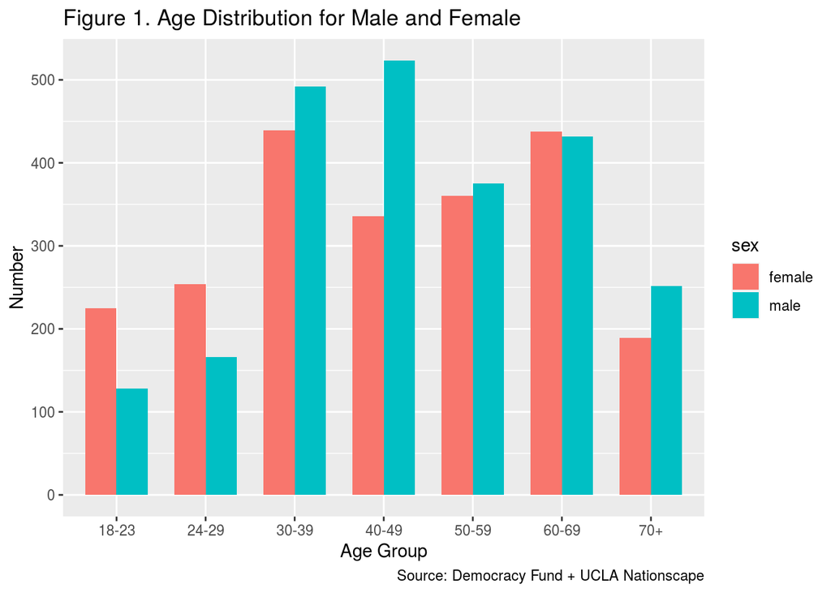

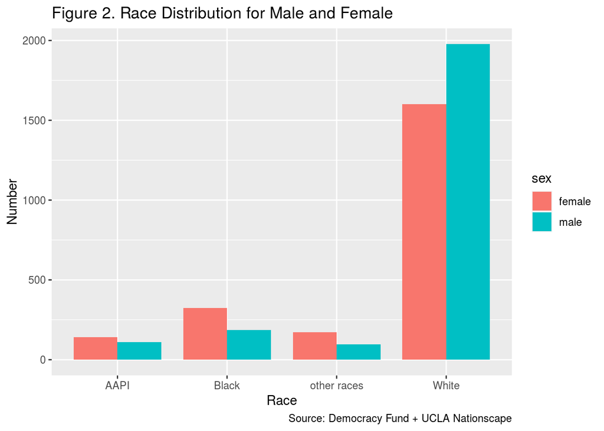

It can be seen from Figure 2 that the vast majority of respondents are white.

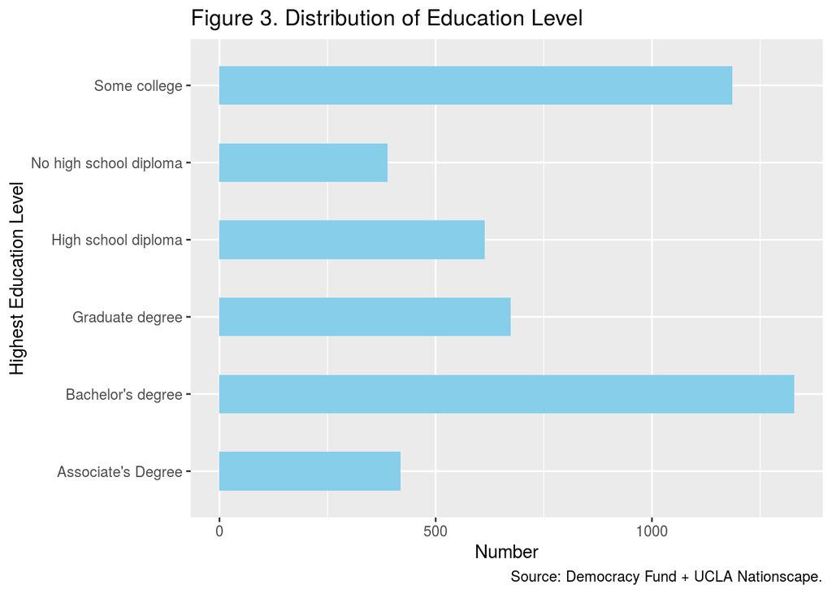

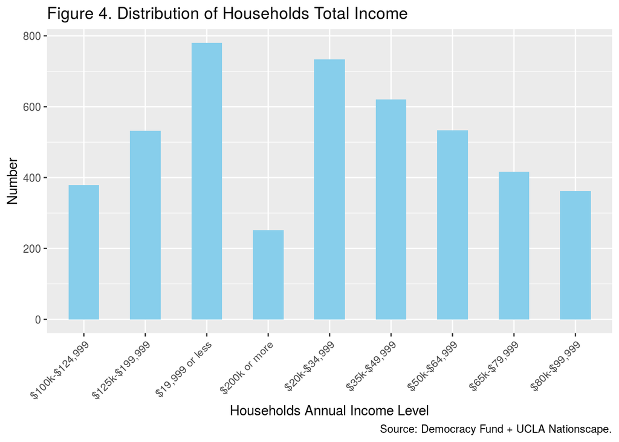

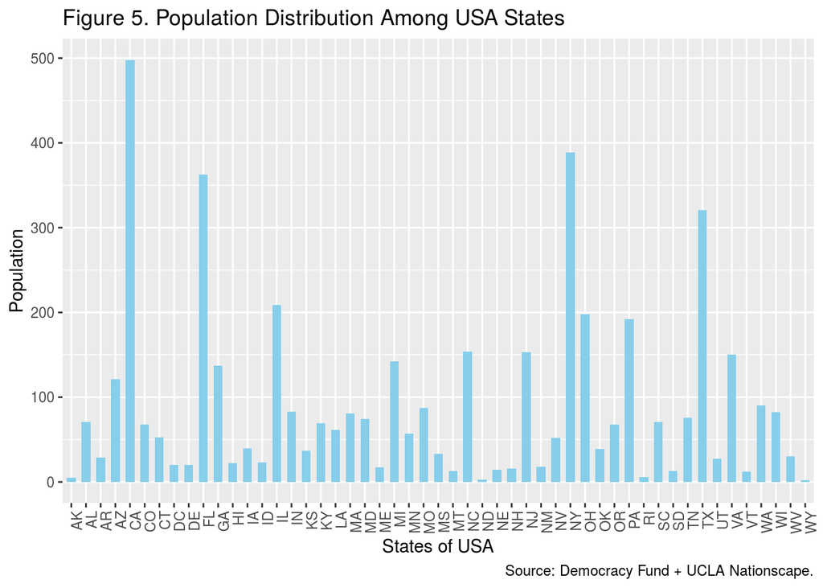

Figure 6 indicates that there are more people who vote for Biden than Trump.

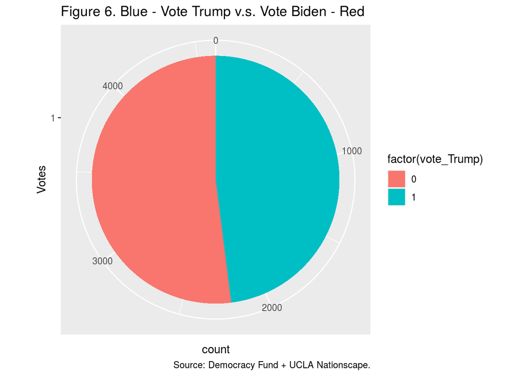

## Post-stratification Data

The data set of American Community Surveys (ACS) collected by IPUMS was treated as the post-stratification data in this analysis and we used the ACS data set in the year of 2018 in this study. (Steven Ruggles and Sobek (n.d.))

The target population of 2018 ACS is the total population living in the United States and the sample frame for the 2018 ACS is a national Master Address File (MAF). MAF was originally created before the 2000 Census and was the first permanently maintained address list of housing units by the Census Bureau. Moreover, the ACS sample design is similar to the Census 2000 long-format sample design, including over-sampling of small government departments, which samples their addresses to improve the reliability of the estimates of small government departments. Since February 2002, the sampling rate in all counties has been reduced to 2.5%, except for Houston, where the sampling rate remains at 1%. Sampling at each site is divided into two stages. 17.5% of the samples are drawn in the first stage, and then a second sampling is performed to reach the final required percentage. Then, one month later, the unanswered households will be contacted by email and telephone. Finally, 1-in-3 non respondents after mail and telephone attempts were selected for personal interviews. Moreover, ACS data are weighted to reflect the sample design by adjusting the impact of non-response, aiming at producing reliable and usable estimated result of the population.

## Data Selection and Visualization

We use the same variables selected in the survey data, which are： age, sex, race, educd, hhincome, citizen,age_group, education, household_income and state.

For data processing, we first deleted the observations who are not eligible to vote, for example, the respondent is under 18 or the respondent is not a citizen. Besides, since the survey data and the post-stratification data are two different data sets, we need the corresponding options for each predictor variable in the two data set. Moreover, we created a categorical variable age_group to represent respondents’ ages in two data set, thereby the age distribution of respondents is much more intuitively. In addition, in order to facilitate the analysis on the variable race, we deleted observations with more than one major race and combined it into 4 categories: AAPI, Black,White and Others.

We draw graphs of variables to generally observe their distribution, which shown as follows.

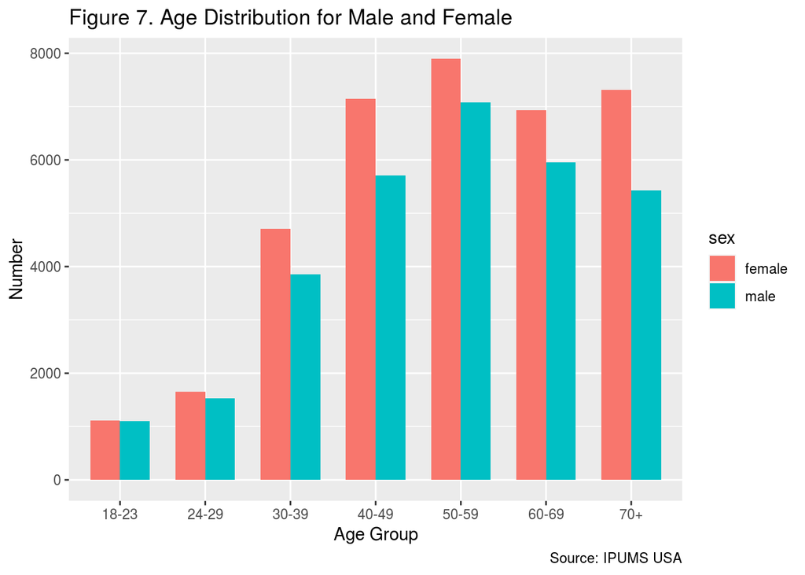

The age distribution of the respondents in Figure 7 is left-skewed, mostly in the middle-aged and middle-aged, and the number of females is larger than that of males in general.

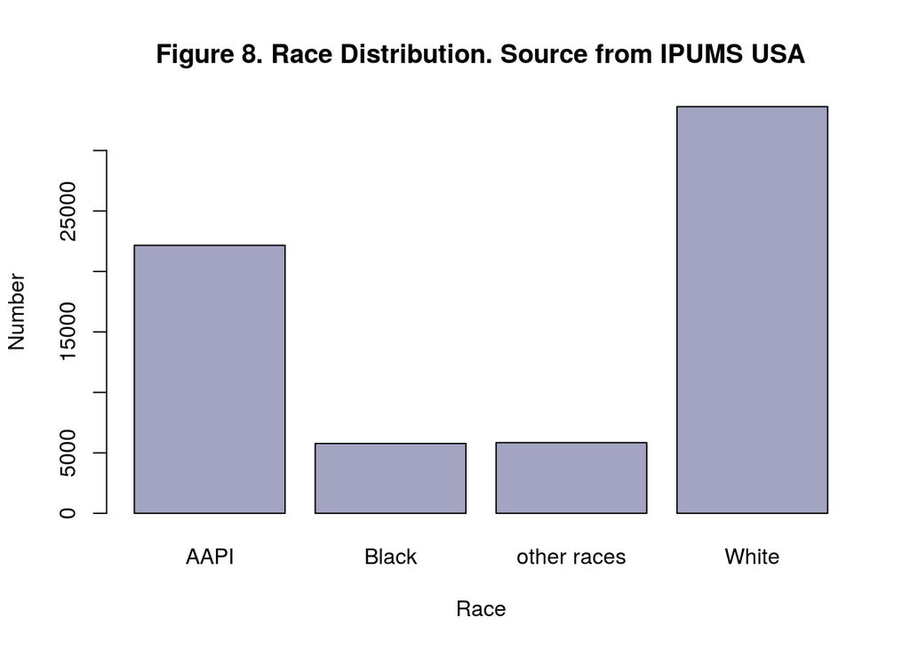

Figure 8 shows that most of the respondents are white, and they account for nearly a half of the proportion, followed by AAPI people.

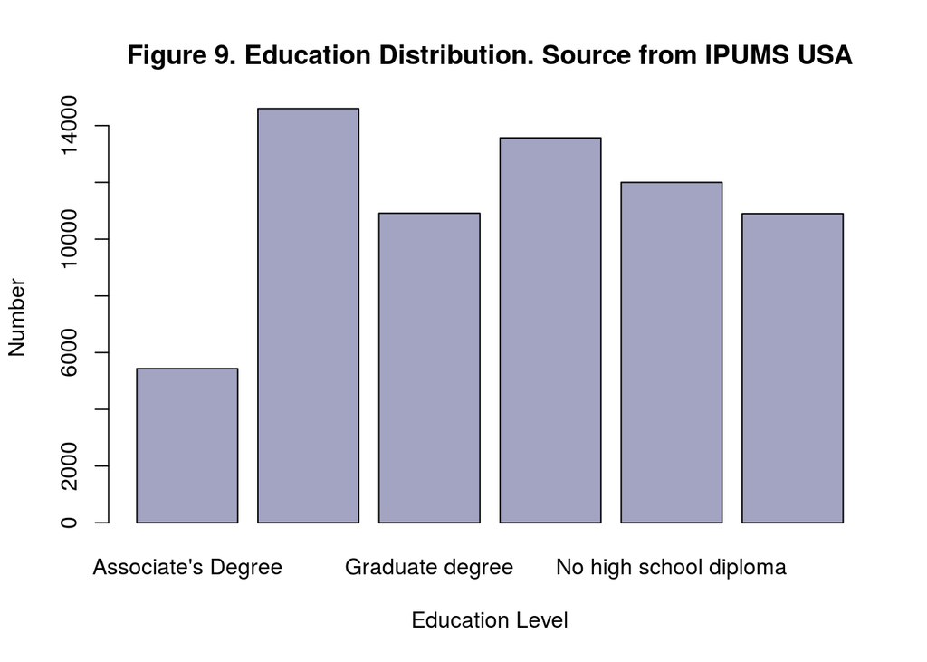

Observed from Figure 9, the most respondents received a bachelor’s degree, followed by a high school diploma.

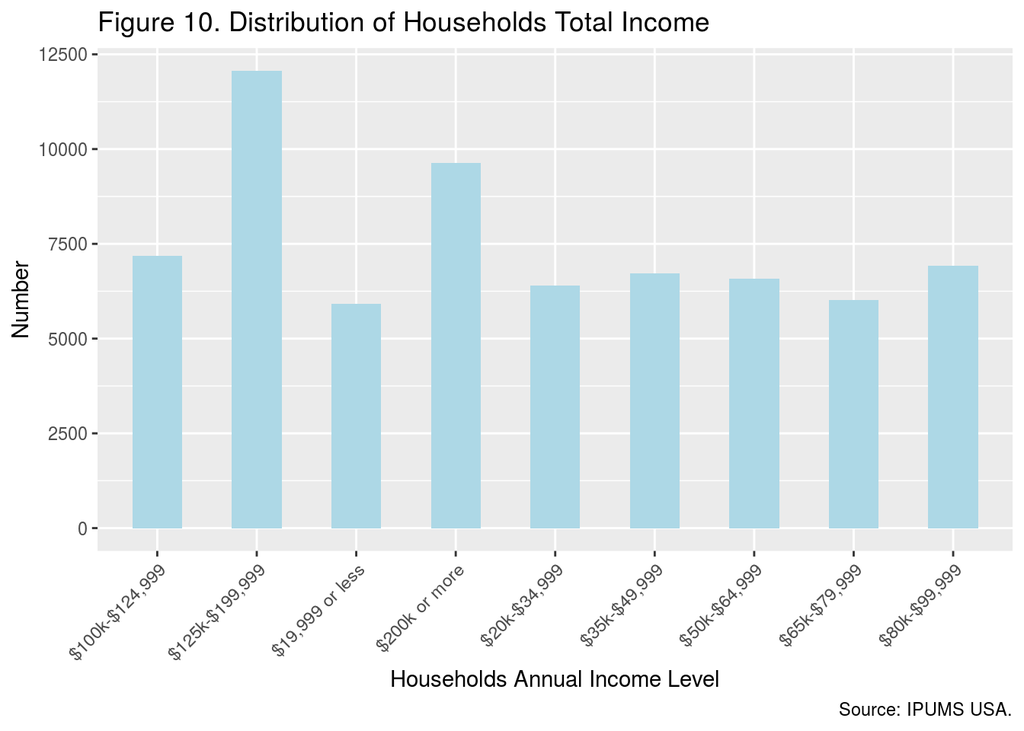

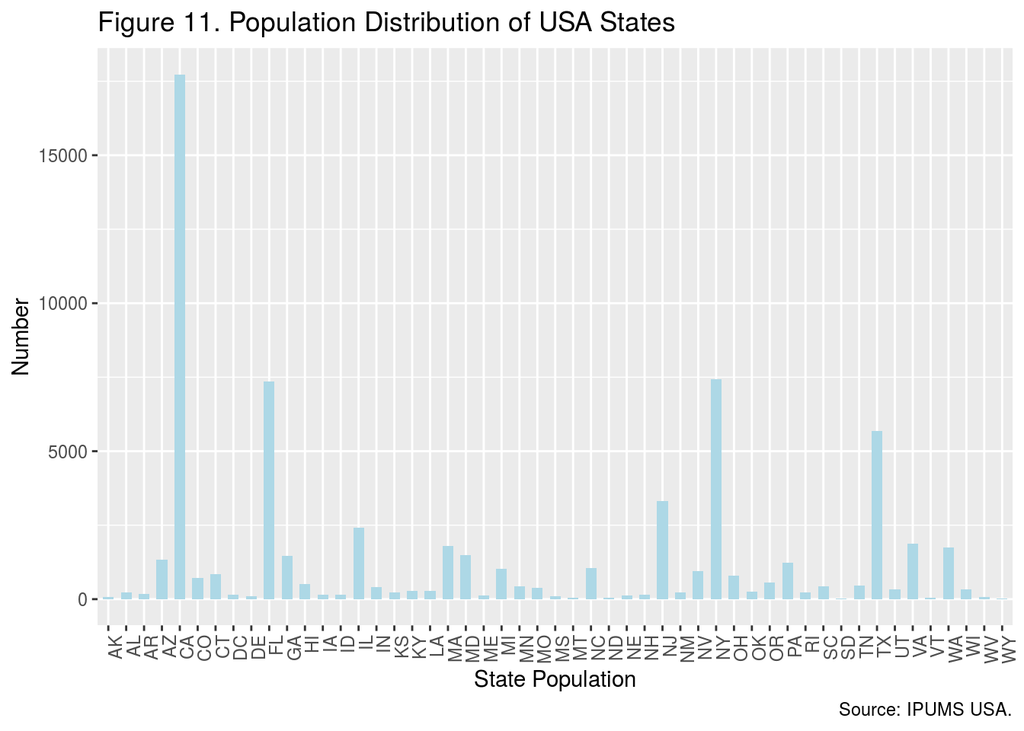

In this analysis, we used R Core Team (2020) as a tool.

# Model

In the above section we have viewed several variables, although all of them might exert observable influence on a person’s intention to vote for Donald Trump, but with the consideration of the capacity of a single computer( which will be discussed later), we maintained three variables: age group, sexuality and race as predictors, in order to build a fitted predicting model, which are the basic features that would pop into our mind while thinking about a human. Instead of using age in numeric form, we classified observations in the data into age group, which enables us to divide people into groups when it comes to a higher level.

By building this model, we applied the method of multilevel regression with post-stratification, which helps to deal with data that observations are grouped. For the individual level we actually build a linear regression model using R (R Core Team (2020)) based on the survey data in 2020(Tausanovitch and Vavreck (2020)), For a multilevel linear regression model, the individual level equation should be like:

$y_{ij} = \beta_{0j} + \beta_{1j}x_{ij} + \epsilon_{ij}$

where y represents the response variable,$\beta_0$ is the intercept, $x_i$ is the predictors that affects $y$, $\beta_1$ is the slope, the extent of influence that changes in $x$ might result in $y$.

When it comes to an election across the country, factors such as the state that the voter lives in would put on a level effect which makes the parameters unstable, and if also the observations are grouped, the coefficients in equation would be like this:

$\beta_{0j} = \alpha + a_j, a_j \sim N(0, {\sigma_a}^2)$ $\beta_{1j} = \beta + b_j, b_j \sim N(0, {\sigma_b}^2)$

This means the parameters varies and follows different normal distribution.

In our case the intention to vote Trump is the response variable, there are three predictors: age, sex and race, people grouped by these predictors, the extent of their influence we could say, vary on different level.

First we look at the linear regression model built based on survey data 2020, using lm() function(Wickham et al. (2019)), at the individual level, there is no specific large VIF(variance inflation factor) values, which indicates that there is no obvious correlation between any two predictors. (used vif()function Fox and Weisberg (2019))

```
##               GVIF Df GVIF^(1/(2*Df))
## age_group 1.075793  6        1.006107
## sex       1.038100  1        1.018872
## race      1.077028  3        1.012444
```

The individual-level linear regression model is fairly fitted, then we directly apply this trained model to the census dataset (ACS 2018)(Rohan Alexander (2020)), when it moves to a higher level, considering state the voter lives in and voters are grouped. For the data that is nearly a census, the ACS 2018 data, we first calculate the number of voters in each possible group combined by state, age group, sex and race, then using the model we could obtain predicted probability for each group, since different group takes different percentage in each state, by calculating the weight of each group and its product with the predicted probability, we can get a state’s predicted probability by adding all of the products.

```
## # A tibble: 51 x 2
##    state predict_prob
##    <chr>        <dbl>
##  1 AK           0.426
##  2 AL           0.433
##  3 AR           0.464
##  4 AZ           0.479
##  5 CA           0.445
##  6 CO           0.475
##  7 CT           0.449
##  8 DC           0.409
##  9 DE           0.413
## 10 FL           0.468
## # … with 41 more rows
```

# Results

From the survey data in 2020 we can calculate the raw probability of people voting for Trump is:

```
## # A tibble: 1 x 1
##   Support_T_raw_prob
##                <dbl>
## 1              0.480
```

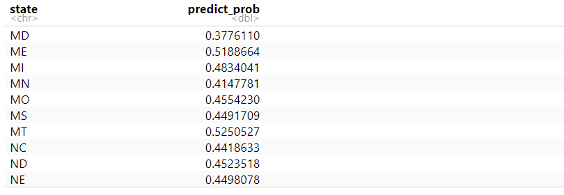

Figure.12

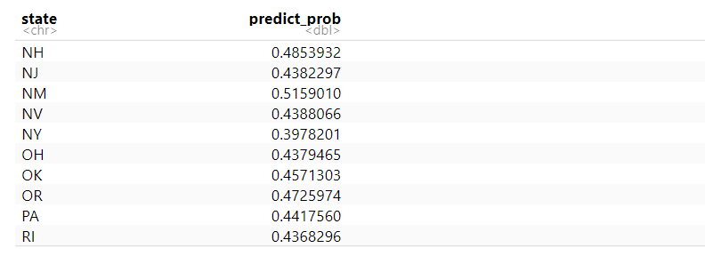

Fig.13

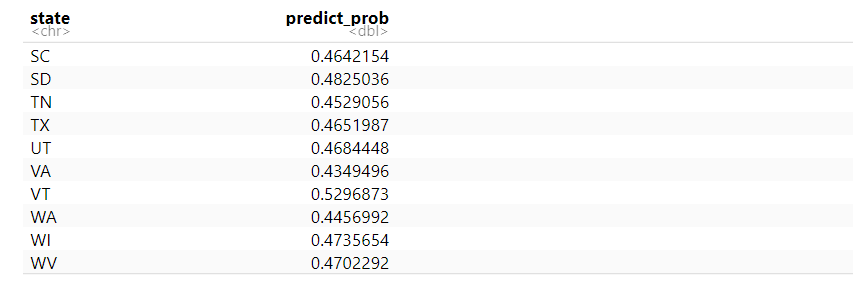

Fig.14

# Discussion

Among these findings, the probability of voting Trump in each state was especially worth mentioning. The voting system in the U.S. indicates that 538 votes are allocated in the electoral college, which are based on states’ representation in Congress, this means that winning a majority of votes is not enough, it is also important to win the votes from swing states. In the past five elections, there were two elections, including the 2016 Trump vs. Clinton election, encountered the situation in which the candidate won the majority of vote did not win the election because they did not maintain their winning seat in electoral college vote (Economist, 2020). Is 2020 election the same case as 2016 election? This is the question we need to ask and investigate. From the model results, we took extra attention on the swing states statistics, and found that the probability of voting Trump in swing states such as Arizona, Minnesota, Florida, were 47.9%, 41% and 46.7% respectively. It seems that Trump lost the majority of vote, but might also lose the electoral college vote as well. However, this still remains uncertain since the voting process is not yet finished, there might be changes in the statistics at the end of the day. Our second finding was that non-white voters tend not to vote for Trump, in other words, a majority of Trump voters were whites. The past research showed that electoral college favours white voters, such that the white share of voting power is about 79% (Economist, 2020). This is an extremely high number, and Trump’s supporters happened to be mainly whites. This implies that the election outcome this year might be the same with the 2016 election, since Trump might win a majority in electoral college again.

For future research, it is best to increase the sample size and select more variables for the model. Also, researchers could try several models and then pick the best one from them. In this report, we did not include model selection process due to a lack of time, this should be fixed in the future.

# Appendix

Code for this analysis is available at: https://github.com/JessieZ32/2020_US_election

# Reference

Fox, John, and Sanford Weisberg. 2019. *An R Companion to Applied Regression*. Third. Thousand Oaks CA: Sage. https://socialsciences.mcmaster.ca/jfox/Books/Companion/.

Larmarange, Joseph. 2020. *Labelled: Manipulating Labelled Data*. http://larmarange.github.io/labelled/.

R Core Team. 2020. *R: A Language and Environment for Statistical Computing*. Vienna, Austria: R Foundation for Statistical Computing. https://www.R-project.org/.

Rohan Alexander. 2020. “Getting Started with Mrp.”

Steven Ruggles, Ronald Goeken, Sarah Flood, and Matthew Sobek. n.d. *IPUMS Usa: Version 10.0 [Dataset]*. Minneapolis, MN: IPUMS, 2020. https://doi.org/10.18128/D010.V10.0.

Tausanovitch, Chris, and Lynn Vavreck. 2020. Democracy Fund + UCLA Nationscape, October 10-17, 2019 (version 20200814). Retrieved from [https://www.voterstudygroup.org/publication/nationscape-data-set].

Wickham, Hadley. 2016. *Ggplot2: Elegant Graphics for Data Analysis*. Springer-Verlag New York. https://ggplot2.tidyverse.org.

Wickham, Hadley, Mara Averick, Jennifer Bryan, Winston Chang, Lucy D’Agostino McGowan, Romain François, Garrett Grolemund, et al. 2019. “Welcome to the tidyverse.” *Journal of Open Source Software* 4 (43): 1686. https://doi.org/10.21105/joss.01686.

Wickham, Hadley, and Evan Miller. 2020. *Haven: Import and Export ’Spss’, ’Stata’ and ’Sas’ Files*.